# Visualizing Big Data in R-Using Trelliscope

# R packages for this project

```r
library(remotes)

pacman::p_load(tibble,
               ggplot2,
               readr,
               hexbin,
               fst,
               ggcorrplot,
               trelliscopejs,
               plotly)
```

# Trelliscope

Trelliscope provides a way to flexibly visualize large, complex data in great detail from within the R statistical programming environment.Trelliscope provides a scalable way to break a set of data into pieces, apply a plot method to each piece, and then arrange those plots in a grid and interactively sort, filter, and query panels of the display based on metrics of interest. With Trelliscope, we are able to create multipanel displays on data with a very large number of subsets and view them in an interactive and meaningful way.

# Task 1: Too many points - point size, transparency, transformations

In this section I look at the LA home prices dataset to explore ways of reducing overplotting.

## Learning objectives

- Understands that one cause of overplotting in scatter plots is simply that there are too many points.
- Can apply point size adjustments, transparency, and axis scale transformations to reduce overplotting problems.
- Can draw and interpret a hex plot.

## Exploring the dataset

```r
data_file <- "data/LAhomes.csv"
```

Read in the dataset from `data_file`, assigning the result to `la_homes`. Explore it (using whichever functions you like).

```r
# Read data_file from CSV
la_homes <- read_csv(data_file)
# Explore it
glimpse(la_homes)
```

```
## Rows: 1,594
## Columns: 9
## $ city   <chr> "Long Beach", "Long Beach", "Long Beach", "Long Beach", "Lon...
## $ type   <chr> NA, NA, NA, NA, NA, NA, NA, NA, NA, NA, NA, NA, NA, NA, NA, ...
## $ bed    <dbl> 0, 0, 0, 0, 0, 1, 1, 1, 1, 1, 1, 1, 1, 1, 1, 1, 1, 1, 1, 1, ...
## $ bath   <dbl> 1, 1, 1, 1, 1, 1, 1, 1, 1, 1, 1, 1, 1, 1, 1, 1, 1, 1, 1, 1, ...
## $ garage <chr> NA, NA, NA, "1", "1", NA, NA, NA, NA, NA, NA, NA, NA, "1", "...
## $ sqft   <dbl> 513, 550, 550, 1030, 1526, 552, 558, 596, 744, 750, 750, 791...
## $ pool   <chr> NA, NA, NA, NA, NA, NA, NA, NA, NA, NA, NA, NA, NA, NA, NA, ...
## $ spa    <lgl> NA, NA, NA, NA, NA, NA, NA, NA, NA, NA, NA, NA, NA, NA, NA, ...
## $ price  <dbl> 119000, 153000, 205000, 300000, 375000, 159900, 135000, 1050...
```

- `price` is the sale price of the home, in USD.
- `sqft` is the area of the home in square feet (about 0.1 square meters).

Using `la_homes`, draw a scatter plot of `price` versus `sqft`.

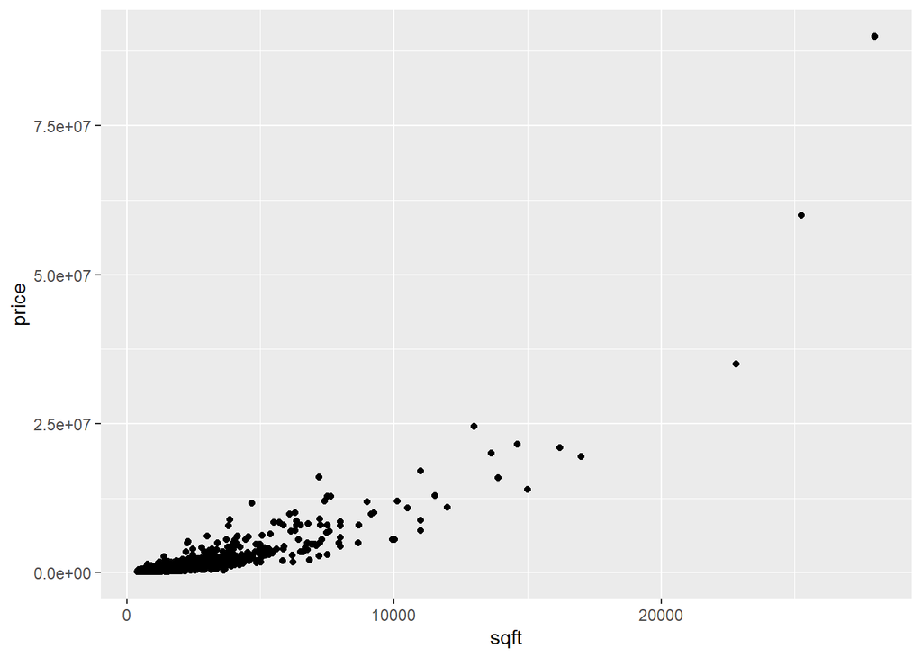

```r
# Using la_homes, plot price vs. sqft with point layer
ggplot(la_homes, aes(sqft, price)) +
  geom_point()
```

## Changing point size

Notice that points in the plot are heavily overplotted in the bottom left corner.

Redraw the basic scatter plot, changing the point size to `0.5`.

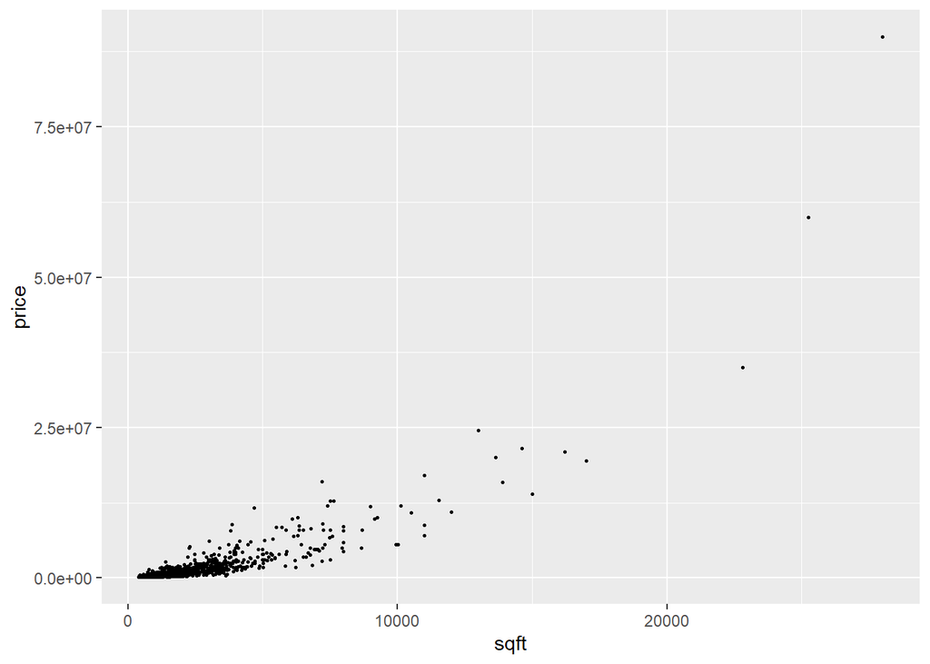

```r
# Draw same scatter plot, with size 0.5
ggplot(la_homes, aes(sqft, price)) +
  geom_point(size = 0.5)
```

Redraw the basic scatter plot, changing the point shape to be “pixel points”.

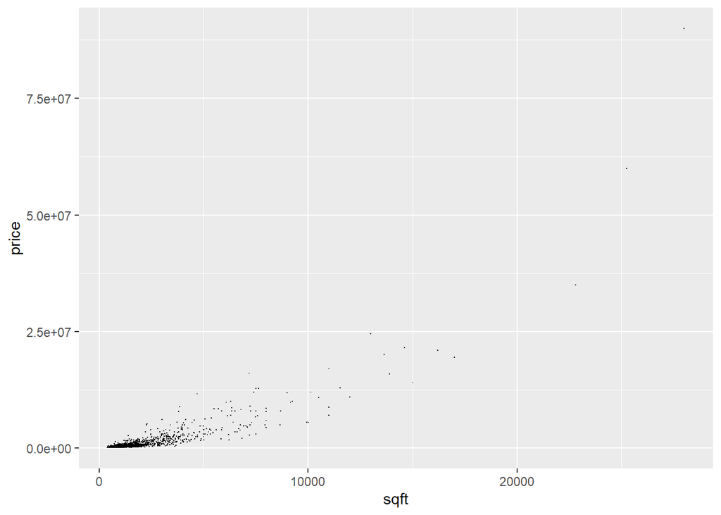

```r
# Draw same scatter plot, with pixel shape
ggplot(la_homes, aes(sqft, price)) +
  geom_point(shape = ".")
```

## Using transparency

Redraw the basic scatter plot, changing the transparency level of points to `0.25`. Set a white background by using ggplot2’s black and white theme.

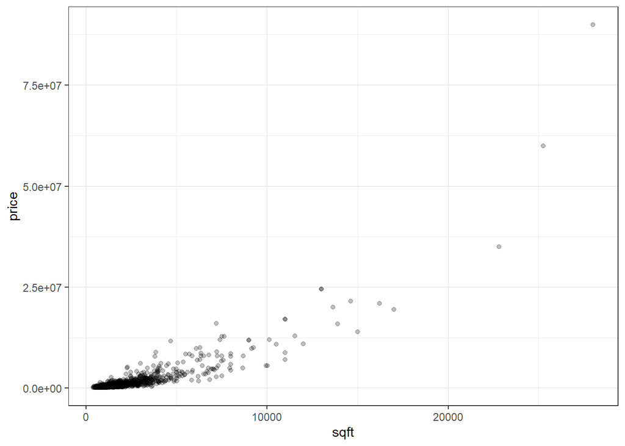

```r
# Draw same scatter plot, with transparency 0.25 and black & white theme
ggplot(la_homes, aes(sqft, price)) +
  geom_point(alpha = 0.25) +
  theme_bw()
```

## Transform the axes

Most of the plots are stuck in the bottom-left corner. Transform the x and y axes to spread points more evenly throughout.

Redraw the basic scatter plot, applying a log10 transformation to the x and y scales.

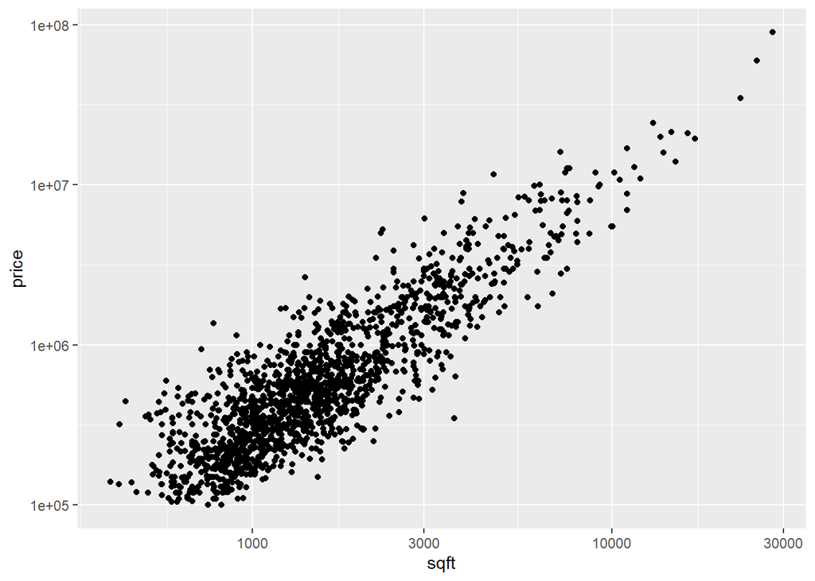

```r
# Draw same scatter plot, with log-log scales
ggplot(la_homes, aes(sqft, price)) +
  geom_point() +
  scale_x_log10() +
  scale_y_log10()
```

Redraw the scatter plot using all three tricks at once.

- Set the point size to `0.5`.
- Set the point transparency to `0.25`.
- Using log10 transformations for the x and y scales.
- Use the black and white theme.

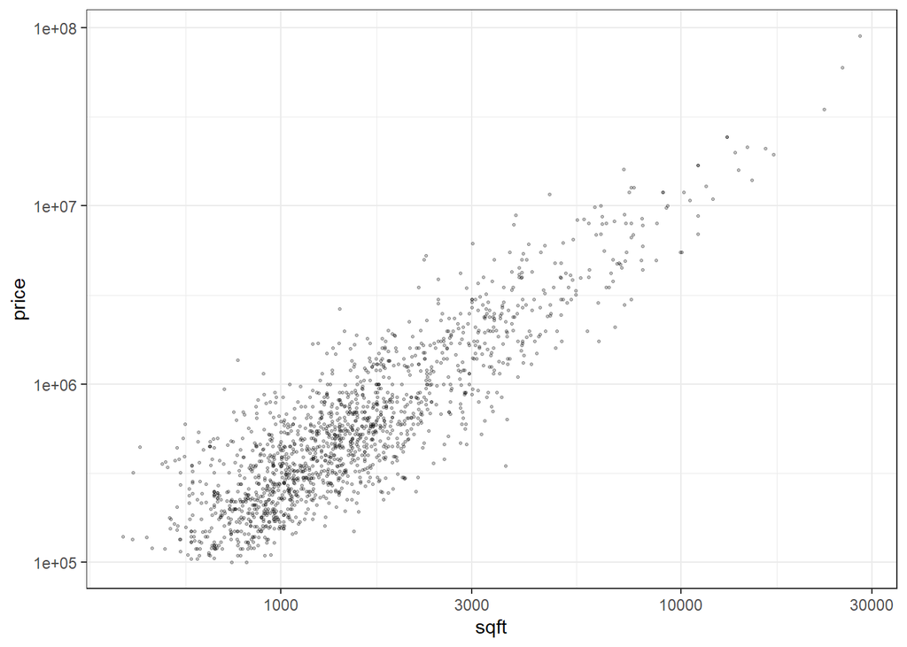

```r
# Draw same scatter plot, with all 3 tricks
ggplot(la_homes, aes(sqft, price)) +
  geom_point(size = 0.5, alpha = 0.25) +
  scale_x_log10() +
  scale_y_log10() +
  theme_bw()
```

## Hex plots

Draw a hex plot of `price` versus `sqft`.

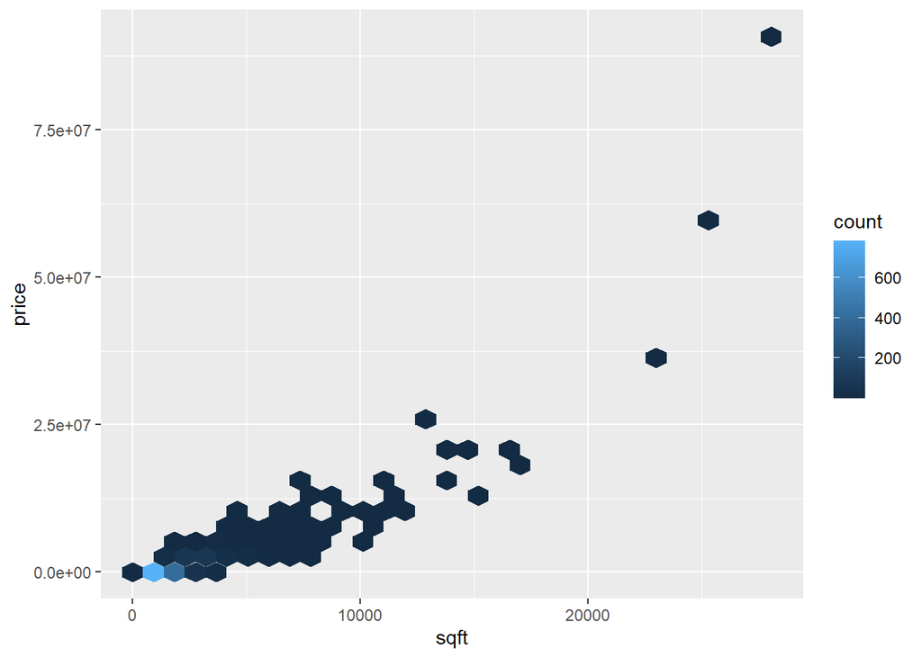

```r
# Using la_homes, plot price vs. sqft with hex layer
ggplot(la_homes, aes(sqft, price)) +
  geom_hex()
```

Redraw the hex plot, applying log10 transformations to the x and y scales.

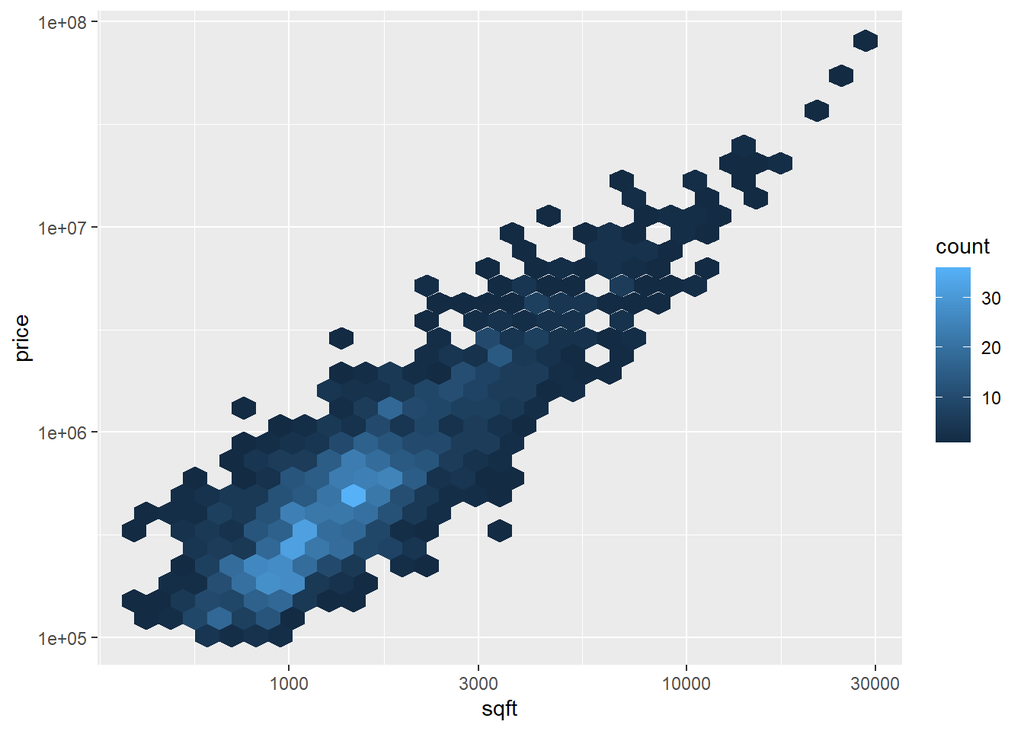

```r
# Draw same hex plot, with log-log scales
ggplot(la_homes, aes(sqft, price)) +
  geom_hex() +
  scale_x_log10() +
  scale_y_log10()
```

- Observation: Log price increases roughly linearly with log area.
- Overplotting: The majority of the houses are found in the region of lightest blues on the hex plot.

# Task 2: Aligned values - jittering

Here you’ll take another look at overplotting in the LA homes dataset.

## Learning objectives

- Understands that one cause of overplotting in scatter plots is low-precision, integer, or categorical variables taking exactly the same values.
- Can apply jittering, transparency, and scale transformations to solve the problem.

# Take a look at the distinct values in `bed` using `distinct()`.

```r
# Look at the distinct values of the bath column
la_homes %>%
  distinct(bed)
```

```
## # A tibble: 13 x 1
##      bed
##    <dbl>
##  1     0
##  2     1
##  3     2
##  4     4
##  5     6
##  6     3
##  7     5
##  8     7
##  9     8
## 10     9
## 11    10
## 12    12
## 13    17
```

## Scatter plots of price vs. bedrooms

Using `la_homes`, draw a scatter plot of `price` versus `bed`.

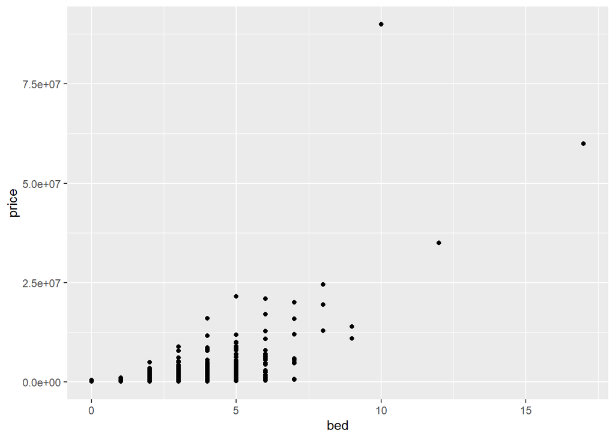

```r
# Using la_homes, plot price vs. bed with a point layer
ggplot(la_homes, aes(bed, price)) +
  geom_point()
```

Draw the same plot again, this time jittering the points along the x-axis.

- Use a maximum jitter distance of `0.4` in the x direction.
- Don’t jitter in the y direction.

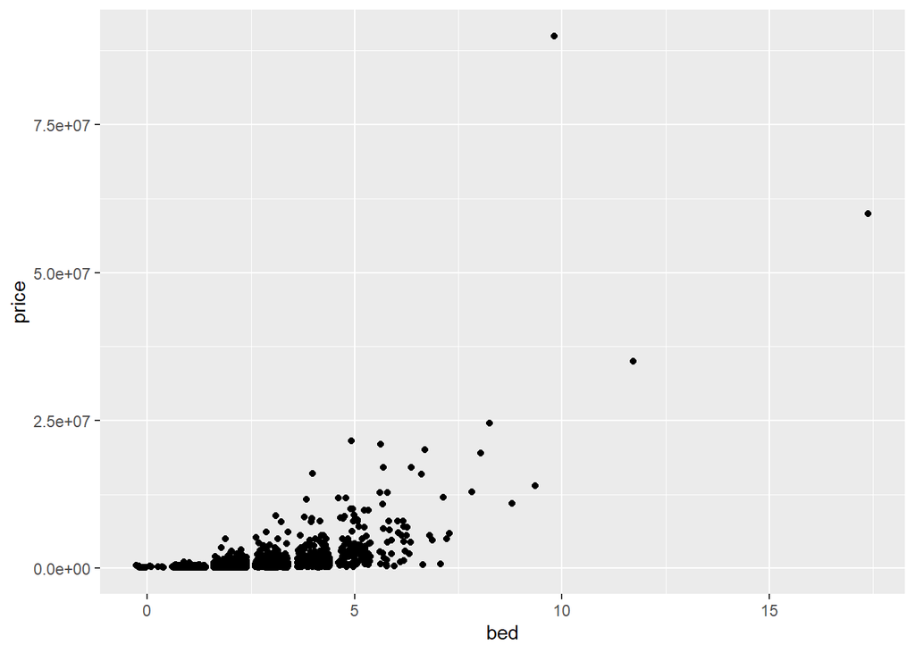

```r
# Draw the previous plot but jitter points with width 0.4
ggplot(la_homes, aes(bed, price)) +
  geom_jitter(width = 0.4, height = 0)
```

Most of the points are near the bottom of the plot.

Draw the same jittered plot again, this time using a log10 transformation on the y-scale.

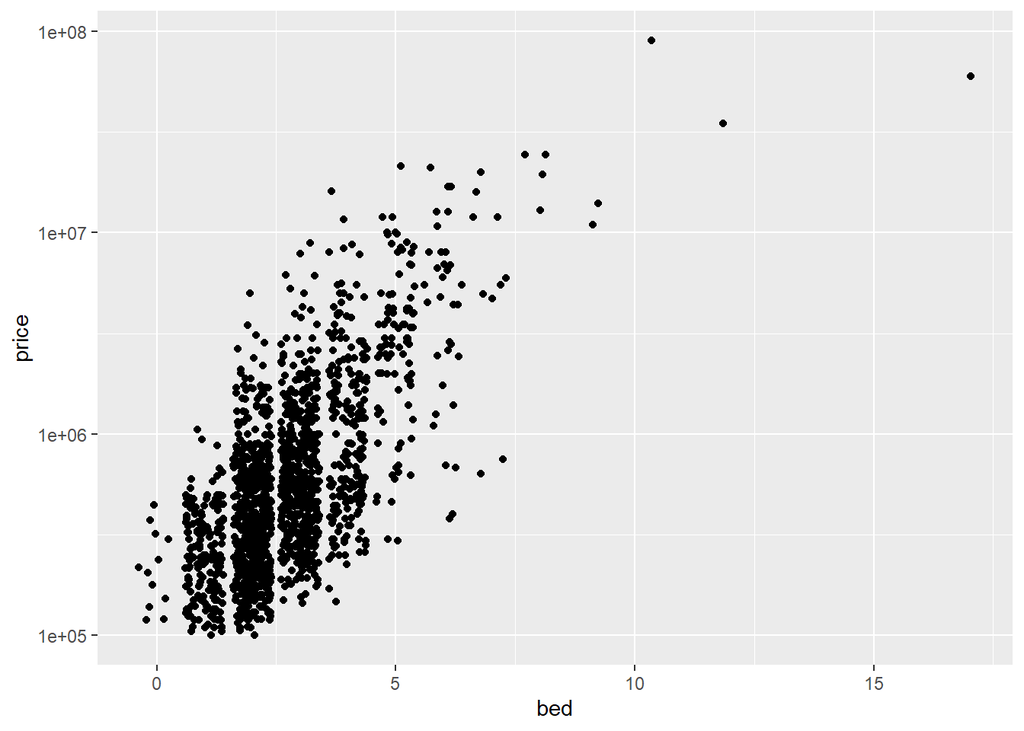

```r
# Draw the previous plot but use a log y-axis
ggplot(la_homes, aes(bed, price)) +
  geom_jitter(width = 0.4, height = 0) +
  scale_y_log10()
```

## Scatter plots of bathrooms vs. bedrooms

- `bath` contains the number of bathrooms in the home.

Take a look at the distinct values in `bath` using `distinct()`.

```r
# Look at the distinct values of the bath column
la_homes %>% distinct(bath)
```

```
## # A tibble: 28 x 1
##     bath
##    <dbl>
##  1   1
##  2   2
##  3   4
##  4   3
##  5   1.5
##  6   2.5
##  7   5
##  8   7
##  9   6
## 10   9
## # ... with 18 more rows
```

Notice that the dataset includes half and quarter bathrooms (whatever they are).

Draw a scatter plot of `bath` versus `bed`.

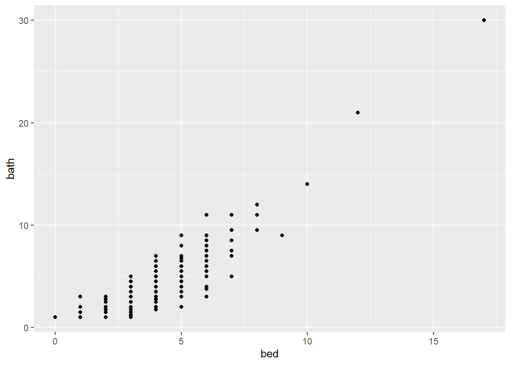

```r
# Using la_homes, plot bath vs. bed with a point layer
ggplot(la_homes, aes(bed, bath)) +
  geom_point()
```

Draw the same plot again, this time jittering the points.

- Use a maximum jitter distance of `0.4` in the x direction.
- Use a maximum jitter distance of `0.05` in the y direction.

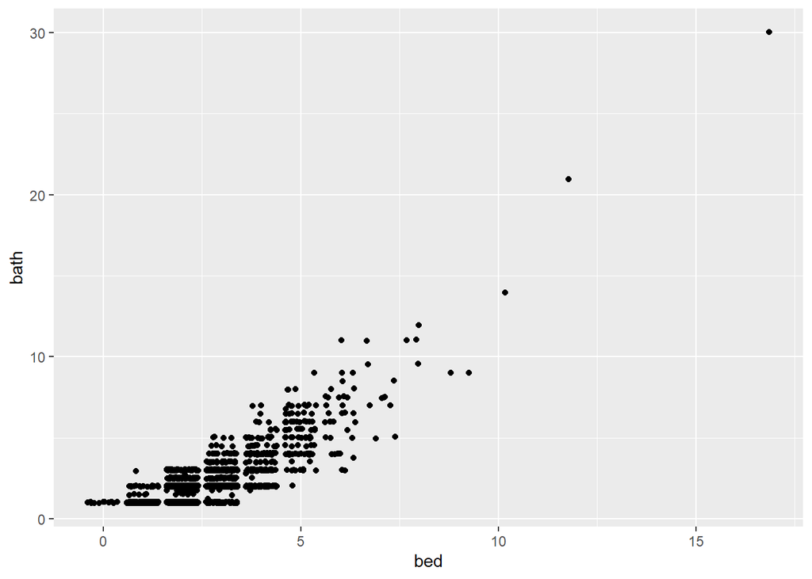

```r
# Using la_homes, plot bath vs. bed with a jittered point layer
ggplot(la_homes, aes(bed, bath)) +
  geom_jitter(width = 0.4, height = 0.05)
```

## Filtering and transformation

There are three homes with 10 or more bedrooms. These constitute outliers, and for the purpose of drawing nicer plots, we’re going to remove them.

Filter `la_homes` for rows where `bed` is less than to `10`, assigning to `la_homes10`. Count the number of rows you removed to check you’ve done it correctly.

```r
# Filter for bed less than 10
la_homes10 <- la_homes %>% filter(bed < 10)

# Calculate the number of outliers you removed
nrow(la_homes) - nrow(la_homes10)
```

```
## [1] 3
```

Draw the same jittered scatter plot again, this time using the filtered dataset (`la_homes10`). As before, use a jitter width of `0.4` and a jitter height of `0.05`.

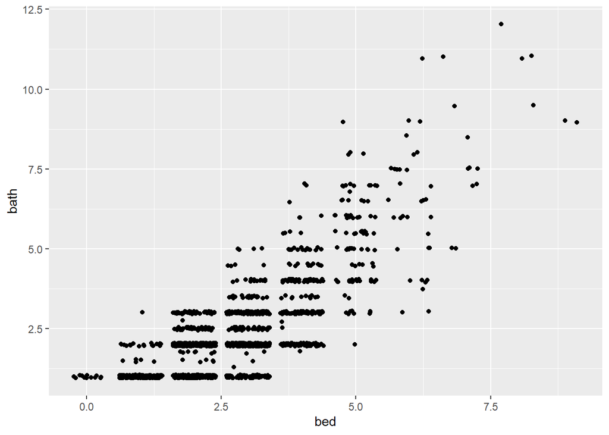

```r
# Draw the previous plot, but with the la_homes10 dataset
ggplot(la_homes10, aes(bed, bath)) +
  geom_jitter(width = 0.4, height = 0.05)
```

Most of the points are towards the bottom left of the plot.

Draw the same jittered scatter plot again, this time applying square-root transformations to the x and y scales.

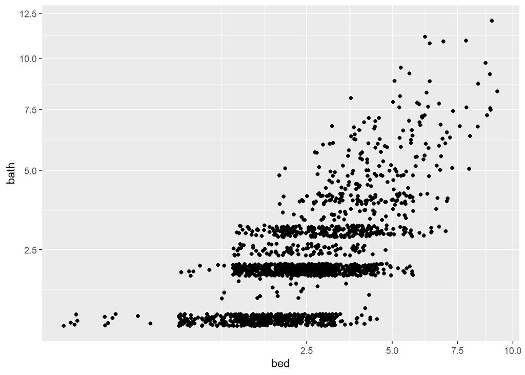

```r
# Draw the previous plot but with sqrt-sqrt scales
ggplot(la_homes10, aes(bed, bath)) +
  geom_jitter(width = 0.4, height = 0.05) +
  scale_x_sqrt() +
  scale_y_sqrt()
```

Refine the plot one more time, by making the points transparent.

[figure not shown]

```r
# Draw the previous plot but with transparency 0.25
ggplot(la_homes10, aes(bed, bath)) +
  geom_jitter(width = 0.4, height = 0.05, alpha = 0.25) +
  scale_x_sqrt() +
  scale_y_sqrt()
```

# Task 3: Too many variables - correlation heatmaps

Here you’ll look at a dataset on Scotch whisky preferences.

## Learning objectives

- Can draw a correlation heatmap.
- Can use hierarchical clustering to order cells in a correlation heatmap.
- Can adjust the color scale in a correlation heatmap.
- Can interpret a correlation heatmap.

## Get the dataset

The dataset is a modified version of `bayesm::Scotch`.

Import the dataset from `scotch.fst` and assign to `scotch`.

```r
# Import from scotch.fst
scotch <- read_fst("data/scotch.fst")

# Explore the dataset, however you wish
glimpse(scotch)
```

```
## Rows: 2,218
## Columns: 20
## $ `Chivas Regal`               <int> 1, 0, 0, 1, 1, 0, 0, 0, 0, 1, 0, 0, 0,...
## $ `Dewar's White Label`        <int> 0, 0, 0, 0, 0, 0, 0, 1, 0, 1, 0, 0, 0,...
## $ `Johnnie Walker Black Label` <int> 0, 1, 0, 1, 1, 0, 0, 0, 0, 0, 0, 0, 1,...
## $ `J & B`                      <int> 0, 0, 0, 0, 0, 0, 0, 1, 0, 0, 0, 1, 0,...
## $ `Johnnie Walker Red Label`   <int> 1, 0, 0, 1, 0, 0, 0, 1, 0, 0, 0, 0, 0,...
## $ Glenlivet                    <int> 1, 0, 0, 1, 0, 0, 1, 0, 0, 0, 0, 0, 0,...
## $ `Cutty Sark`                 <int> 0, 0, 0, 1, 0, 0, 0, 0, 0, 0, 0, 0, 0,...
## $ Glenfiddich                  <int> 1, 0, 0, 0, 0, 0, 0, 0, 0, 0, 0, 0, 0,...
## $ `Pinch Haig`                 <int> 0, 0, 0, 0, 0, 0, 0, 0, 0, 0, 0, 0, 0,...
## $ `Clan Macgregor`             <int> 0, 0, 0, 0, 0, 0, 0, 0, 0, 0, 0, 0, 0,...
## $ Ballantine                   <int> 0, 0, 1, 0, 0, 0, 0, 0, 0, 0, 0, 0, 0,...
## $ Macallan                     <int> 0, 0, 0, 0, 0, 1, 0, 0, 0, 0, 1, 0, 0,...
## $ Passport                     <int> 0, 0, 0, 1, 0, 0, 0, 0, 1, 0, 0, 0, 0,...
## $ `Black & White`              <int> 0, 0, 0, 0, 0, 0, 0, 0, 0, 0, 0, 0, 0,...
## $ `Scoresby Rare`              <int> 0, 0, 0, 0, 0, 0, 0, 0, 0, 0, 0, 0, 0,...
## $ Grants                       <int> 0, 0, 0, 0, 0, 0, 0, 0, 0, 0, 0, 0, 0,...
## $ Ushers                       <int> 0, 0, 0, 0, 0, 0, 0, 0, 0, 0, 0, 0, 0,...
## $ `White Horse`                <int> 0, 0, 0, 0, 0, 0, 0, 0, 0, 0, 0, 0, 0,...
## $ Knockando                    <int> 0, 0, 0, 0, 0, 0, 0, 0, 0, 0, 0, 0, 0,...
## $ `The Singleton`              <int> 0, 0, 0, 0, 0, 0, 1, 0, 0, 0, 0, 0, 0,...
```

## Draw a basic correlation heatmap

Calculate the correlation matrix for `scotch`, assigning to `correl`.

```r
# Calculate the correlation matrix
correl <- cor(scotch)
```

Draw a correlation heatmap of it (no customization).

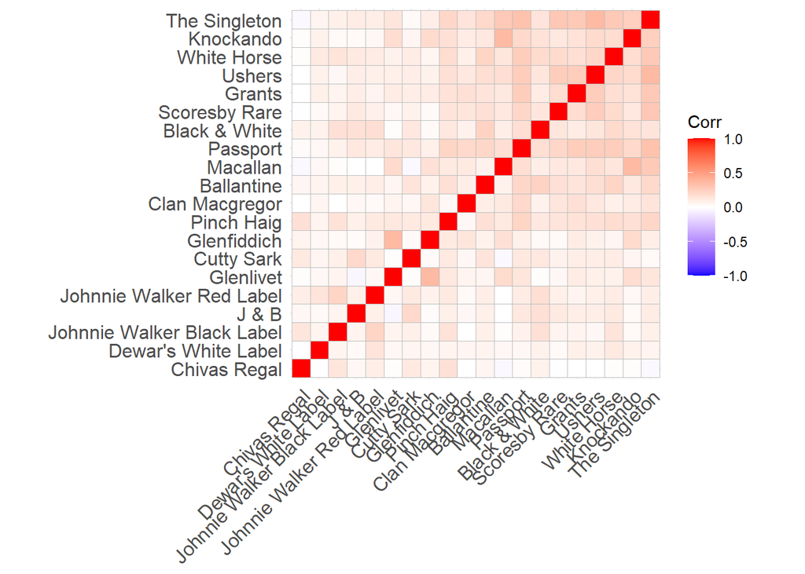

```r
# Draw a correlation heatmap
ggcorrplot(correl)
```

## Drop redundant cells

Draw the previous plot again, this time only showing the upper triangular portion of the correlation matrix.

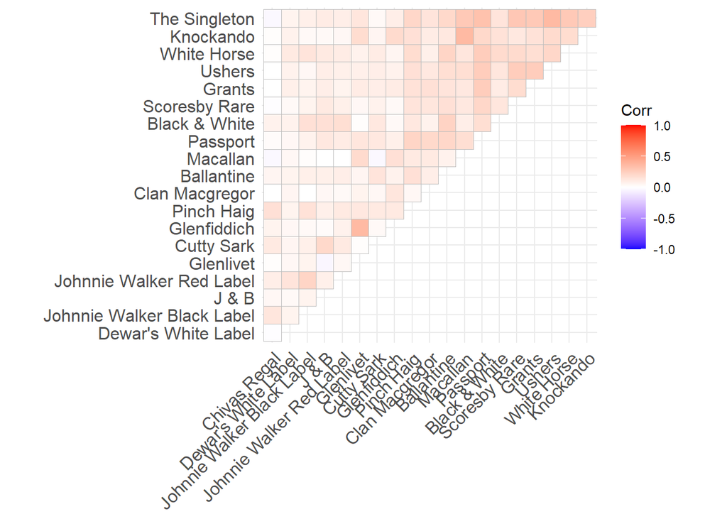

```r
# Draw a correlation heatmap of the upper triangular portion
ggcorrplot(correl, type = "upper")
```

## Use hierarchical clustering

Draw the previous plot again, this time using hierarchical clustering to reorder cells.

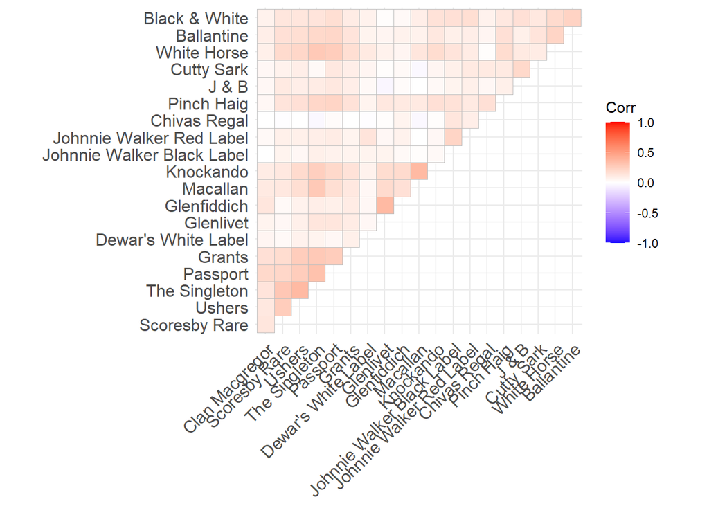

```r
# Draw a correlation heatmap of the upper triangular portion
ggcorrplot(correl, type = "upper", hc.order = TRUE)
```

# Override the color scale

Set the diagonal values in the correlation matrix to `NA`, then calculate the range of the correlation matrix.

```r
# Set the diagonals of correl to NA
diag(correl) <- NA

# Calculate the range of correl (removing NAs)
range(correl, na.rm = TRUE)
```

```
## [1] -0.03983478  0.36044648
```

We have both positive and negative correlations, so this is a slightly trickier situation than in the slides. We want a symmetric color scale centered on zero.

Define the limits of the color scale.

- Calculate the `max`imum `abs`olute correlation (removing NAs). Assign to `max_abs_correl`.
- Add some padding to `max_abs_correl` (any small number). Assign to `max_abs_correl_padded`.
- Define the scale limits as the vector (`-max_abs_correl_padded`, `max_abs_correl_padded`).

```r
# Calculate the largest absolute correlation (removing NAs)
max_abs_correl <- max(abs(correl), na.rm = TRUE)

# Add some padding
max_abs_correl_padded <- max_abs_correl + 0.02

# Define limits from -max_abs_correl_padded to max_abs_correl_padded
scale_limits <- c(-max_abs_correl_padded, max_abs_correl_padded)
```

Draw the previous plot again, this time overriding the fill color scale.

- Add `scale_fill_gradient2()`.
- Pass the scale limits.
- Set the `high` argument to `"red"`.
- Set the `mid` argument to `"white"`.
- Set the `low` argument to `"blue"`.

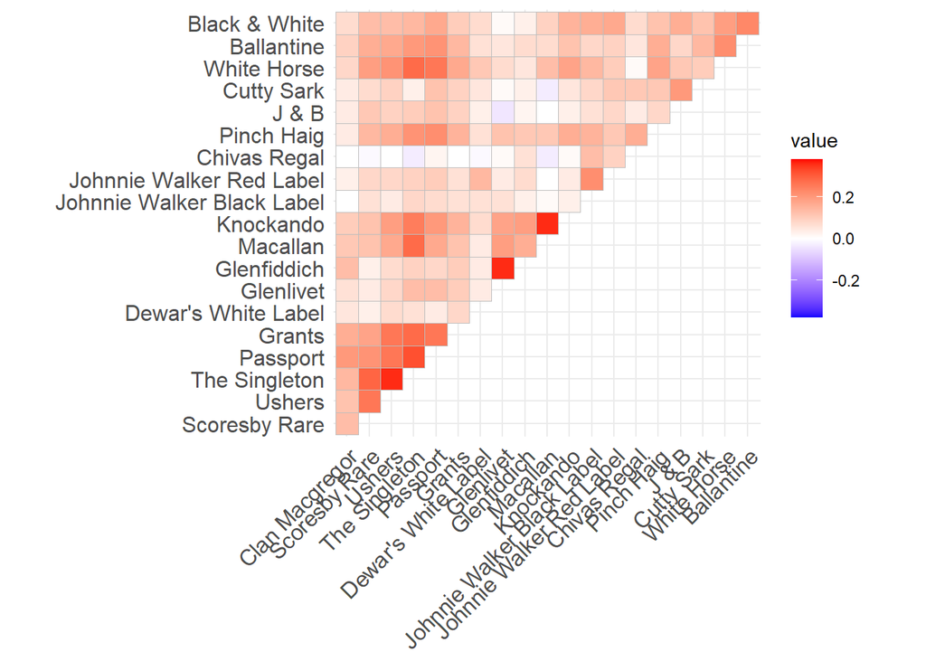

```r
# Draw a correlation heatmap of the upper triangular portion
# Override the fill scale to use a 2-way gradient
ggcorrplot(correl, type = "upper", hc.order = TRUE) +
  scale_fill_gradient2(
    limits = scale_limits,
    high = "red",
    mid = "white",
    low = "blue"
  )
```

## Interpreting correlation heatmaps

Drinkers of Glenfiddich are most likely to also drink Glenlivet Drinkers of Knockando are most likely to also drink Macallan

# Task 4: Too many facets - trelliscope plots

Here, you’ll explore the 30 stocks in the Dow Jones Industrial Average (DJIA).

## Learning objectives

- Can convert a ggplot into a trelliscope plot.
- Can use common arguments to control the appearance of a trelliscope plot.
- Can use the interactive filter and sort tools to interpret a trelliscope plot.

## Get the dataset

Import the DJIA data from `dow_stock_prices.fst`, assigning to `dow_stock_prices`. Explore it however you wish.

```r
# Import the dataset from dow_stock_prices.fst
dow_stock_prices <- read_fst("data/dow_stock_prices.fst")

# Explore the dataset, however you wish
glimpse(dow_stock_prices)
```

```
## Rows: 22,065
## Columns: 9
## $ symbol            <chr> "UNH", "UNH", "UNH", "UNH", "UNH", "UNH", "UNH", ...
## $ company           <chr> "UnitedHealth Group", "UnitedHealth Group", "Unit...
## $ sector            <chr> "Health Care", "Health Care", "Health Care", "Hea...
## $ date              <date> 2017-01-03, 2017-01-04, 2017-01-05, 2017-01-06, ...
## $ volume            <dbl> 3539700, 2695200, 2961100, 3081300, 3040800, 3500...
## $ adjusted          <dbl> 153.6547, 154.0925, 154.3494, 154.5683, 154.1305,...
## $ relative          <dbl> 0.5214050, 0.5228906, 0.5237626, 0.5245054, 0.523...
## $ date_of_max_price <date> 2019-12-27, 2019-12-27, 2019-12-27, 2019-12-27, ...
## $ date_of_min_price <date> 2017-02-17, 2017-02-17, 2017-02-17, 2017-02-17, ...
```

Take a look at the range of the dates in the dataset.

```r
# Get the range of the dates in dow_stock_prices
range(dow_stock_prices$date)
```

```
## [1] "2017-01-03" "2019-12-31"
```

## From ggplot2 to trelliscopejs

Using `dow_stock_prices`, draw a line plot of `relative` versus `date`, faceted by `symbol`.

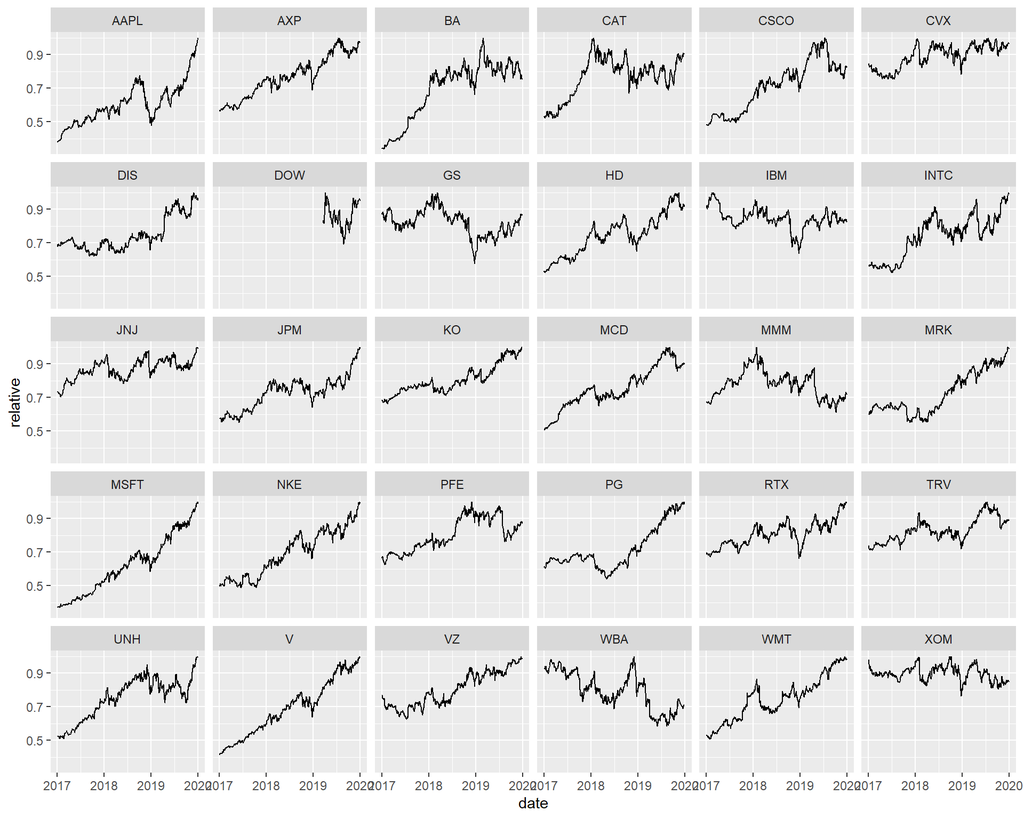

```r
# Using dow_stock_prices, plot relative vs. date
# as a line plot
# faceted by symbol
ggplot(dow_stock_prices, aes(date, relative)) +
  geom_line() +
  facet_wrap(vars(symbol))
```

Redraw the previous plot, this time as a trelliscope plot (no customization).

- Set the `path` argument to `"trelliscope/basic"`.

```r
# Same plot as before, using trelliscope
ggplot(dow_stock_prices, aes(date, relative)) +
  geom_line() +
  facet_trelliscope(
    vars(symbol),
    path = "trelliscope/basic"
  )
```

```
## using data from the first layer
```

[interactive chart not shown]

# Improving the plot

We can improve on the previous plot by customizing it.

Redraw the previous plot, with the following changes.

- Set the `path` argument to `"trelliscope/improved"`.
- Set the plot title to `Dow Jones Industrial Average`.
- Set the plot description to `Share prices 2017-01-01 to 2020-01-01`.
- Arrange the panels in `5` rows of `2` columns per page.
- Increase the width of each panel to `1200` pixels.

```r
# Draw the same plot again, customizing the display
# Set path, name, desc, nrow, ncol, width
ggplot(dow_stock_prices, aes(date, relative)) +
  geom_line() +
  facet_trelliscope(
    vars(symbol),
    path = "trelliscope/improved",
    name = "Dow Jones Industrial Average",
    desc = "Share prices 2017-01-01 to 2020-01-01",
    nrow = 5,
    ncol = 2,
    width = 1200
  )
```

```
## using data from the first layer
```

[interactive chart not shown]

## Filtering

-Information Technology sector contains the most companies

- Exxon Mobil `Energy` sector company began 2020 with a lower share price than 2017
- How many companies had a maximum price more than double the minimum price during the time period? That is, how many companies had a relative minimum less than `0.5`? Ans = 6

# Sorting Questions

Based on mean daily volume of trades, which company was the 3rd most traded during the time period?

- AAPL (Apple)
- MSFT (Microsoft)
- CSCO (Cisco Systems)
- PFE (Pfizer)
- INTC (Intel)

Which company’s median relative price during the time period was lowest?

## Free scales

The relative share prices were plotted to make it easier to compare performance between companies. If you want to plot the non-normalized `adjusted` prices, you need to give each panel its own y-axis.

Redraw the previous plot, with these changes.

- Set the `path` argument to `"trelliscope/yscale"`.
- On the y-axis, plot `adjusted` rather than `relative`.
- Give each panel a free y-axis scale (while keeping the x-axis scales the same).

```r
# This time plot adjusted vs. date
# Use a free y-scale
ggplot(dow_stock_prices, aes(date, adjusted)) +
  geom_line() +
  facet_trelliscope(
    vars(symbol),
    path = "trelliscope/yscale",
    name = "Dow Jones Industrial Average",
    desc = "Share prices 2017-01-01 to 2020-01-01",
    nrow = 5,
    ncol = 2,
    width = 1200,
    scales = c("same", "free")
  )
```

```
## using data from the first layer
```

[interactive chart not shown]

Which company, at it’s maximum, had the highest price for 1 share?

- BA (Boeing)
- GS (Goldman Sachs Group)
- UNH (UnitedHealth Group)
- AAPL (Apple)
- MMM (3M)

## Interactive plotting with plotly

By using plotly to create each panel, each panel becomes interactive. Hover over the line to see the values of individual points.

Redraw the previous plot, using plotly to create the panels.

- Set the `path` argument to `"trelliscope/plotly"`.

```r
# Redraw the last plot using plotly for panels
ggplot(dow_stock_prices, aes(date, adjusted)) +
  geom_line() +
  facet_trelliscope(
    vars(symbol),
    path = "trelliscope/plotly",
    name = "Dow Jones Industrial Average",
    desc = "Share prices 2017-01-01 to 2020-01-01",
    nrow = 5,
    ncol = 2,
    width = 1200,
    scales = c("same", "free"),
    as_plotly = TRUE
  )
```

```
## using data from the first layer
```

```
## PhantomJS not found. You can install it with webshot::install_phantomjs(). If it is installed, please make sure the phantomjs executable can be found via the PATH variable.
```

```
## * could not create htmlwidget thumbnail... will use blank thumbnail...
```

[interactive chart not shown]